# Thirties

Ota Brzák

2025-10-28

# The rules of the game

For this game analysis, I will be using slightly modified rules of the dice game 30s. The rules go like this: player starts with 30 lives and the players take turns clockwise. At the start of a turn, a player gets 6 dice. The goal of a player’s turn is to throw the highest sum of all dice, which can be 36 at best.

The turn goes like this: the player throws all dice and has to set aside at least 1 of them. After he sets some dice aside (1 or more), he throws the rest of them again and repeats the process (sets at least 1 ř aside, throws the rest again), until there are no dice to throw and all are set aside. Since each throw contains at least 1 less die than the previous, the player can throw as many as 6 times in a turn.

After the final throw, the dice are summed up. If the result is lower than 30 (this is a recurring number in this game, as the name suggests), difference from 30 is subtracted from the player’s lives (if I throw a 27, I lose 3 lives). If the result is higher than 30, the surplus over 30 is subtracted from the lives of the player on the left (if I throw a 35, the player on my left loses 5 lives). The last player with any lives left wins.

The scoring is not too important in this analysis, let’s just establish that we want to find a strategy, that gets us as much above 30 as possible (ideally as close to 36 as possible). Let’s now try to find it!

# Simplest strategy

Ok, a simple strategy would be to keep all the higher numbers and rethrow all the lower numbers. To keep it simple, let’s set aside all 5’s and 6’s and look at what we get.

```
## [1] 31
```

Now let’s think about this for a minute. Imagine I throw a 5 in a last throw (only 1 die remaining). The expected value for the throw of 1 die is 3,5 and we scored much higher! Great.

But now, what if I throw a 5 in my first throw (with all 6 dice). Is it a good result, or is it not? As we can see, it now gets a bit more complicated. After this first throw, I will have the opportunity to see 15 more dice thrown (5 + 4 + 3 + 2 +1) and there is a pretty good chance we will see a 6 come up (to be exact it is $1-\left(\frac{5}{6}\right)^{15}=0.935$).

This changes our strategy a lot. Theoretically, for each throw ranging from 1 die to 6 dice there is a threshold that tells us whether to keep that die or not. That threshold is different for every throw, starts high and gradually lowers. But just where might this threshhold lie?

# Order statistics

This threshold is called the expected value. Expected value is the weighted average of all possible outcomes and shows us the average result of a throw or even a whole turn. We should start keeping numbers above expected value and try again with numbers below the expected value,

In the previous strategy, we only decided to keep 6s and 5s. Could we improve our strategy by computing the expected value of the next throw based on number we throw with? Let’s try to estimate the maximum value thrown by $n$ dice, since we only need to keep 1 die (logically, we want to keep the highest value from a throw).

If we denote the $k$th order statistic ($k$th lowest element in the sample) as $X_{(k)}$, the probability that the element will equal some value $x$ is computed as

$${\displaystyle {\begin{aligned}P(X_{(k)}=x)&=\sum _{j=0}^{n-k}{n
\choose
j}\left((1-F(x))^{j}(F(x))^{n-j}-(1-F(x)+f(x))^{j}(F(x)-f(x))^{n-j}\right).\end{aligned}}}$$

However, since we are looking for a maximum ($k=n$), we can simplify this formula. Let’s denote three following values:
$$\mathbf{p_{1}}=P(X<x)=F(x)-f(x),
\mathbf{p_{2}}=P(X=x)=f(x),{\text{ and
}}\mathbf{p_{3}}=P(X\>x)=1-F(x).$$

Using these, we can transform the formula and simplify:

$${\displaystyle {\begin{aligned}P(X_{(k)}=x)&=\sum _{j=0}^{n-k}{n
\choose
j}\left((1-F(x))^{j}(F(x))^{n-j}-(1-F(x)+f(x))^{j}(F(x)-f(x))^{n-j}\right),\\&=\sum
_{j=0}^{n-k}{n \choose
j}\left(p_{3}^{j}(p_{1}+p_{2})^{n-j}-(p_{2}+p_{3})^{j}(p_{1})^{n-j}\right),\\&=\sum_{j=0}^{n-n}{n\choose
0} \left( p_3^0(p_1+p_2)^n- (p_2 + p_3)^0(p_1)^n\right),
\\&=(p_1+p_2)^n-p_1^n,
\\&=F(x)^n-\left(F(x)-f(x)\right)^n
\\\end{aligned}}}$$

To build a better strategy, we first need a theoretical baseline. We can use the order statistics to calculate the expected maximum value for a roll of *n* dice. This helps us understand what a “good” roll looks like.

The `e_max()` function will give us the expected maximum value from throwing *n* dice. In 30s, the expected value of the *n*th order statistic (the maximum) look like this:

```r
n_range <- 6:1
expected_maxima <- round(e_max(n_range), digits = 2)
data.frame(n = n_range, expected_maximum = expected_maxima)
```

```
##   n expected_maximum
## 1 6             5.56
## 2 5             5.43
## 3 4             5.24
## 4 3             4.96
## 5 2             4.47
## 6 1             3.50
```

# Turn simulation

For further simulation and examination of solutions, we will code a function that simulates a turn based on our strategy (a vector of 6 thresholds).

# Brute force solution

If we think the actual space of possible solutions, in this case, it is not really that large. There are a few rules that cut down on the number of solutions greatly:

1. Each vector has exactly 6 elements, with each element being 1 of 6 possible values.
2. Even with 1 die, we expect to roll 3.5 on average. That means that with 1 or more dice still in play (this is true constantly), we should not settle with anything less than a 4. This cuts the number of possible solutions in half (we only settle for 4s, 5s, or 6s).
3. Our expected value from a single throw goes down with the amount of dice in that throw. By this idea we can ignore all threshold vectors, in which any value in position i is greater than the value in position i-1.

Implementing all of these ideas, we are left with 28 vectors for which these rules are true.

```
##    T1 T2 T3 T4 T5 T6 score
## 1   6  6  6  6  6  6     0
## 2   6  6  6  6  6  5     0
## 3   6  6  6  6  5  5     0
## 4   6  6  6  5  5  5     0
## 5   6  6  5  5  5  5     0
## 6   6  5  5  5  5  5     0
## 7   5  5  5  5  5  5     0
## 8   6  6  6  6  6  4     0
## 9   6  6  6  6  5  4     0
## 10  6  6  6  5  5  4     0
## 11  6  6  5  5  5  4     0
## 12  6  5  5  5  5  4     0
## 13  5  5  5  5  5  4     0
## 14  6  6  6  6  4  4     0
## 15  6  6  6  5  4  4     0
## 16  6  6  5  5  4  4     0
## 17  6  5  5  5  4  4     0
## 18  5  5  5  5  4  4     0
## 19  6  6  6  4  4  4     0
## 20  6  6  5  4  4  4     0
## 21  6  5  5  4  4  4     0
## 22  5  5  5  4  4  4     0
## 23  6  6  4  4  4  4     0
## 24  6  5  4  4  4  4     0
## 25  5  5  4  4  4  4     0
## 26  6  4  4  4  4  4     0
## 27  5  4  4  4  4  4     0
## 28  4  4  4  4  4  4     0
```

Now we simulate 10000 turns for each strategy vector and compute the average score.

```r
print(valid_vectors)
```

```
##    T1 T2 T3 T4 T5 T6   score
## 1   6  6  6  6  6  6 29.8368
## 2   6  6  6  6  6  5 29.8877
## 3   6  6  6  6  5  5 30.0671
## 4   6  6  6  5  5  5 30.0461
## 5   6  6  5  5  5  5 29.9267
## 6   6  5  5  5  5  5 29.7263
## 7   5  5  5  5  5  5 29.6893
## 8   6  6  6  6  6  4 29.9007
## 9   6  6  6  6  5  4 30.1146
## 10  6  6  6  5  5  4 30.1273
## 11  6  6  5  5  5  4 29.9746
## 12  6  5  5  5  5  4 29.8256
## 13  5  5  5  5  5  4 29.7051
## 14  6  6  6  6  4  4 29.9768
## 15  6  6  6  5  4  4 29.9495
## 16  6  6  5  5  4  4 29.7799
## 17  6  5  5  5  4  4 29.6507
## 18  5  5  5  5  4  4 29.5407
## 19  6  6  6  4  4  4 29.7373
## 20  6  6  5  4  4  4 29.4382
## 21  6  5  5  4  4  4 29.2707
## 22  5  5  5  4  4  4 29.1677
## 23  6  6  4  4  4  4 29.2360
## 24  6  5  4  4  4  4 28.8057
## 25  5  5  4  4  4  4 28.6970
## 26  6  4  4  4  4  4 28.6029
## 27  5  4  4  4  4  4 28.3104
## 28  4  4  4  4  4  4 28.2979
```

Since the scores still might be inaccurate, Let’s pick top 3 solutions and simulate 1000000 turns for each one.

```
## iteration 1 out of 3
## iteration 2 out of 3
## iteration 3 out of 3
```

```
##    T1 T2 T3 T4 T5 T6  score threshold_label
## 10  6  6  6  5  5  4 30.077     6,6,6,5,5,4
## 9   6  6  6  6  5  4 30.136     6,6,6,6,5,4
## 3   6  6  6  6  5  5 30.108     6,6,6,6,5,5
```

# Genetic algorithm

We have already found the top solution through brute force. However, with higher number of options the time to find the optimal solution would grow exponentially (the brute force algorithm has complexity of $\mathcal{O}(2^n)$, which is absolutely horrible). Could there be another way of finding a solution?

Brute force worked here because the constrained search space (28 vectors) was small. For more complex scenarios (e.g., allowing lower thresholds), this approach becomes computationally overwhelming. Since this game has a very large ammount of outcomes, it would be super tedious to solve analytically. The way to go here is to look into a more efficient optimization algorithm.

In this case, we do not have any continuous function to optimize. Therefore, I implemented a genetic algorithm as a more scalable optimization method and to verify the brute-force result.

```
## [1] 1 1 1 6 6 6
```

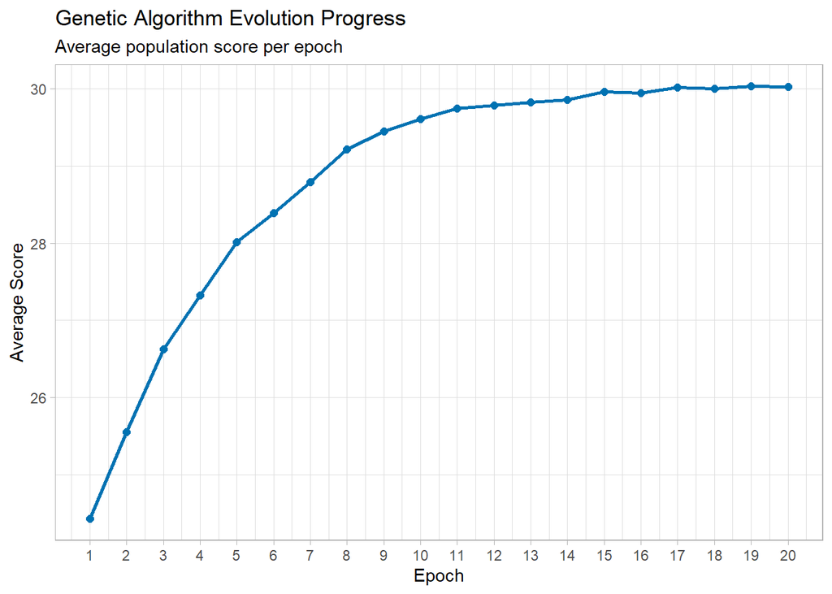

```r
p2 <- evolution$p2
evolved_population <- evolution$population
print(p2)
```

```r
ggsave("evolution_results_plot.png", plot = p2, width = 8, height = 5)
```

# Conclusions

## Comparing the solutions

We print out both of our best solutions and compare them.

```r
cat("Brute force result:","\n",as.numeric((best_vectors[which.max(best_vectors$score),1:7])))
```

```
## Brute force result:
##  6 6 6 6 5 4 30.136
```

```r
cat("\n","\n")
```

```r
cat("GA result:","\n",as.numeric(evolved_population[which.max(evolved_population$score),]))
```

```
## GA result:
##  6 6 6 5 5 3 30.293
```

```
## 95% CI: [ 29.953 , 30.319 ]
```